# Práctico N°2

13-08-2021

# 0. Objetivo del práctico

El objetivo de este práctico es crear nuestro primer reporte en **RMarkdown** y contener en este el **primer paso de un código en R: cargar paquetes**.

Para ello repasaremos algunos conceptos básicos de R y Markdown, y los pasos necesarios para la creación de su propio archivo en .Rmd. Este práctico será clave para la realización de tu tarea N°1

## Materiales de la sesión

Recuerden que los archivos asociados a este práctico se pueden descargar aquí:

- 02-class.zip

## 1. Conceptos clave

[**RMarkdown**](https://rmarkdown.rstudio.com/) es un archivo que puede integrar código de R (mediante chunks) y texto en [**Markdown**](https://learn-r-uah.netlify.app/resource/markdown/) a la vez. Todo el sitio web de este curso está creado con RMarkdown (y [un paquete llamado **blogdown**](https://bookdown.org/yihui/blogdown/)).

**RMarkdown** tienen una estructura de al menos 3 partes

1. Encabezado (YAML)
2. Texto
3. Código de R

¡Vamos a profundizar en cada una de ellas! Pero antes te iremos mostrando el paso a paso para crear un archivo en .Rmd

## 2. Paso a paso para crear un RMarkdown

### Paso 1: Instalación de paquetes

Como vimos en la sesión, para la creación de un RMarkdown necesitamos dar una extensión a R que le permita “compilar” los archivos construidos en .Rmd a formatos como `.pdf`, `.html`, `.doc`. Para ello instalaremos 2 paquetes `knitr` y `rmarkdown`

Usualmente para cargar paquetes lo hacemos de la siguiente manera:

```r
  install.packages("paquete")
  library(paquete)
```

Pero en esta ocasión utilizaremos un paquete llamado **pacman**, este facilita y agiliza la lectura de los paquetes a utilizar en R. De esta forma lo instalamos 1 única vez así:

```r
install.packages("pacman")
library (pacman)
```

Luego cargaremos así los paquetes de R, esto agiliza la carga de paquetes. Para este práctico cargaremos el paquete **rmarkdown** y **knit**.

```r
pacman::p_load(rmarkdown,
               knit)
```

### Paso 2: Crear un nuevo archivo en Rmarkdown

1. Una vez cargados los paquetes deben dirigirse a `File > New File > R Markdown`

[figure not shown]

2. Luego deben darle un título, poner su nombre y especificar un *formato de salida* ya sea en **HTML**, **PDF** o **Word**

[figure not shown]

3. Les creará un archivo con un *YAML*, que tendrá la información general del documento y un *chunk*

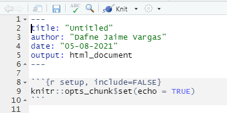

4. Ya pueden comenzar a escribir sus informes en RMarkdown. Veremos en seguida las configuraciones para dejarlo más lindo

[figure not shown]

### Paso 3: Crear el archivo con formato desde el .Rmd

Es el botón que permite *compilar* (tejer o unir) el documento que hemos escrito. Combinará tanto el código de R y el texto, a partir de las instrucciones que dimos en el YAML (¡y por eso es tan importante también!)

[figure not shown]

Es **importante** que sepan que cuando se hace **Knit**, R ejecuta cada uno de los trozos **secuencialmente**. El proceso que sigue no es necesario que lo entiendas a cabalidad (aún) [^1], lo importante es que debes saber que si todo lo que está dentro de tu .Rmd está bien hecho deberías ver como resultado un archivo en el formato de salida que definiste en tu YAML (.pdf, .doc)

## 3. Configuraciones del RMarkdown

### 3.1 Encabezado (YAML)

Al inicio del Markdown siempre debemos poner algunas informaciones sobre el documento, por ejemplo, el título, la fecha, autor, etc. Esta parte del Markdown se llama [YAML](https://learn.getgrav.org/16/advanced/yaml).

Básicamente, con esto establecemos las “configuraciones” del texto.

Por ejemplo, si queremos que nuestro archivo esté en PDF, colores, si queremos que incluya bibliografía, entre otros. La “cabeza” del Markdown o **YAMLS** está dividida del resto del cuerpo del texto al inicio y al final con tres líneas (`---`).

```yaml
---
title: Título de mi tesis
date: "16 de Agosto, 2021"
author: "Estudiante UAH"
---
```

Debes poner este texto entre comillas. Si quieres ocupar comillas dentro de tu título, puedes utilizar comillas simples (e.g. mi tesis se titula `Mi tesis: la más "genial" de Chile`), entonces ponemos

```yaml
---
title: `Mi tesis: la más "genial" de Chile`
---
```

#### Instrucciones de salida en YAML (Output formats)

Los formatos de salida se ven en el encabezado (**YAML**) del documento, aquí puedes especificar en qué formato quieres que te entregue tu archivo. De esta forma puedes especificar qué tipo de documento creas cuando *“Kniteas”* (es como *“tejer”*, *construir*)

```yaml
---
title: "Mi documento"
output:
  html_document: default
  pdf_document: default
  word_document: default
---
```

También puedes hacer click en la flecha hacia abajo del botón “Knit” para elegir la salida *y* generar el YAML apropiado. Si hace click en el icono del engranaje junto al botón “Knit” y elige “Output options” (opciones de salida), puede cambiar la configuración para cada tipo de salida en específico, como las dimensiones de las figuras por defecto o si se incluye o no un índice.

[figure not shown]

El primer tipo de salida que aparece en `output:` será el que se genere al pulsar el botón **“Knit”** o al pulsar el atajo de teclado (`⌘⇧K` en macOS; `control + shift + K` en Windows). Si elige una salida diferente con el menú del botón “Knit”, esa salida se moverá a la parte superior de la sección `output`.

##### Adicionales en YAML

El encabezado o YAML es importante, especialmente cuando tienes configuraciones anidadas bajo cada tipo de salida. Cuando uno ya está más avanzado así es como una sección `output` suele verse:

```yaml
---
title: "Mi tesis"
author: "Valentina Andrade"
date: "16 Agosto 2021"
output:
  html_document:
    theme: cerulean
    toc: true
    toc_depth: 2
    toc_float: true
    number_sections: true
  pdf_document:
    latex_engine: xelatex  # Para hacer pdf
    toc: true
  word_document:
    toc: true
---
```

En el **YAML** o **encabezado** del documento, se puede modificar:

- `title` y `subtitle`: es el título y subtítulo. Como cualquier carácter en R lo mejor es poner entre comillas su contenido
- `author`: nombre del autor/a
- `date`: fecha, puede ser escrita como ustedes quieran
- `output`: opciones de salida (html, pdf, doc, ¡incluso ppt!)
  - `toc`: “Table of contents” o en español, índice. El término `depth` indica “profundidad” para ver cuántos títulos mostrar y `float` para ver si se desliza automáticamente

Si quieres ver más opciones, [temas para tu documento puedes ver aquí](https://bookdown.org/yihui/rmarkdown/html-document.html)

### 3.3 Código en R (Chunks)

Para ingresar **trozos** de código en R a nuestro documento ocuparemos los **chunks**. Estos permiten hacer análisis estadísticos dentro del documento visualizando los resultados en el documento final

#### 3.3.1 Añadir Chunks

Hay tres formas de insertar chunks:

1. Pulsar `⌘⌥I` en macOS o `Control + Alt + I` en Windows
2. Pulsa el botón “Insert” en la parte superior de la ventana del editor

[figure not shown]

3. Escribirlo manualmente (no recomendado)

#### 3.3.2 Nombrar chunks

Se puede añadir nombres a los chunks para hacer más fácil la navegación por el documento. Si haces clic en el pequeño menú desplegable en la parte inferior de tu editor en RStudio, puedes ver una tabla de contenidos que muestra todos los títulos y chunks. Si nombras los chunks, aparecerán en la lista. Si no incluyes un nombre, el chunk seguirá apareciendo, pero no sabrás lo que hace.

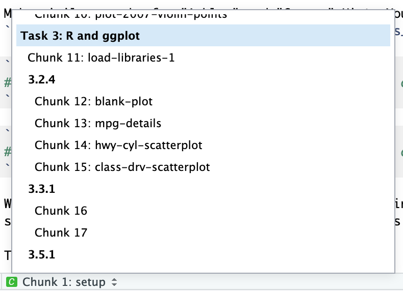

Para añadir un nombre, inclúyelo inmediatamente después de la `{r` en la primera línea del chunk. Los nombres no pueden contener espacios, pero sí guiones bajos y guiones.

Importante: **Todos los nombres de chunk de tu documento deben ser únicos.**

#### 3.3.3 Opciones de chunks

Hay un montón de opciones diferentes que puedes establecer para cada chunk. Puedes ver una lista completa en la [Guía de referencia de RMarkdown](https://rstudio.com/wp-content/uploads/2015/03/rmarkdown-reference.pdf) o en el [sitio web de **knitr**](https://yihui.org/knitr/options/).

Las opciones de chunk más comunes son estas:

- `fig.width=5` y `fig.height=3` (*o el número que quieras*): Establece las dimensiones de las figuras
- `echo=FALSE`: El código no se muestra en el documento final, pero los resultados si
- `message=FALSE`: Se omiten los mensajes que genera R (como todas las notas que aparecen después de cargar un paquete)
- `warning=FALSE`: Se omiten las advertencias que genera R
- `include=FALSE`: El chunk se sigue ejecutando, pero el código y los resultados no se incluyen en el documento final

También puedes configurar las opciones del chunk haciendo clic en el pequeño icono del engranaje en la esquina superior derecha de cualquier chunk:

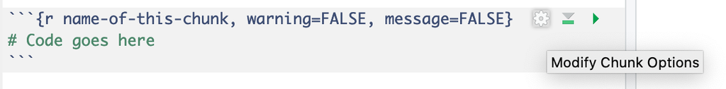

## 4. Resumen

Dentro de la creación de archivos en RMarkdown, hay algunos **conceptos claves** que si o si debes manejar para ir construyendo tus documentos en RMarkdown.

1. **YAML**: Es un encabezado al inicio del documento que inicia y acaba con tres guiones **—***. Acá se introducen aspectos básicos del documento, como el título, el autor, la fecha y el formato de salida (output)
2. **Chunk**: son **trozos** de códigos de R, estor permiten hacer análisis estadísticos dentro del documento visualizando los resultados en el documento final
3. **Knit**: Es el botón que permite *compilar* (tejer o unir) el documento que hemos escrito. Combinará tanto el código de R y el texto, a partir de las instrucciones que dimos en el YAML

### 4.1 Actividad del práctico

La actividad tendrá relación con la entrega de la **Tarea 1**. Esta actividad consiste en la creación de un RMarkdown que contenga lo siguiente:

- Un encabezado (YAML) con el título: “Práctico 2”. También deben incorporar su nombre y fecha
- Este encabezado debe tener una salida (output), deben elegir `html_output`
- En el documento deben incorporarla imagen `grafico01` (que está en el .zip asociado a la clase)
- Finalmente, deben crear una tabla simple.

## 5. Recursos

- [RMarkdown en Ciencia de Datos - Hadley Whickham](https://es.r4ds.hadley.nz/r-markdown.html)
- [R Markdown](https://rmarkdown.rstudio.com/)
- [Tutoriales Markdown](https://rmarkdown.rstudio.com/lesson-1.html)
- [cheatsheets](https://www.rstudio.com/wp-content/uploads/2015/02/rmarkdown-cheatsheet.pdf)
- Para practicar ir a [Tutorial de Markdown](https://www.markdowntutorial.com/es/)

## 6. Reporte de progreso

¡Recuerda rellenar tu reporte de progreso! En https://learn-r.formr.org/. Te llegó un código único a tu correo electrónico. Mediante él debes acceder para actualizar tu estado de avance del curso.

[^1]: Luego de apretar knit, se convierte la salida de cada trozo en un archivo intermedio en Markdown. Luego, RStudio hace “pasar” ese documento vía [pandoc](https://pandoc.org/) para convertirlo en HTML o PDF o Word (o cualquier salida que haya seleccionado).